# examples_0109

Simplify the following powers of $i$.

- $i^{34}=$
- $i^{39}=$
- $i^{44}=$
- $i^{57}=$

For any positive integer $n$, we can evaluate $i^n$ by determining the remainder when $n$ is divided by 4.

| Remainder of $n/4$ | $i^n$ |
| --- | --- |
| 0 | $1$ |
| 1 | $i$ |
| 2 | $-1$ |
| 3 | $-i$ |

In computer programming, the [modulo operator](https://en.wikipedia.org/wiki/Modulo) returns the remainder. This operation is used so frequently, that it is often abbreviated to a single symbol (for example, in Python, `5%2` represents the remainder when 5 is divided by 2.)

I will represent the remainders using the [Desmos](https://www.desmos.com/calculator) notation.

- $\mathrm{mod}(34,4)=2$ so $i^{34}=-1$
- $\mathrm{mod}(39,4)=3$ so $i^{39}=-i$
- $\mathrm{mod}(44,4)=0$ so $i^{44}=1$
- $\mathrm{mod}(57,4)=1$ so $i^{57}=i$

To find the remainder using a scientific calculator, I would divide by 4, [floor](https://en.wikipedia.org/wiki/Floor_and_ceiling_functions) the result, multiply by 4, and subtract that amount from the original.

$$\mathrm{mod}(x,4)~=~x-4\cdot
\left\lfloor\frac{x}{4}\right\rfloor$$

Simplify the following powers of $i$.

- $i^{24}=$
- $i^{31}=$
- $i^{49}=$
- $i^{54}=$

For any positive integer $n$, we can evaluate $i^n$ by determining the remainder when $n$ is divided by 4.

| Remainder of $n/4$ | $i^n$ |
| --- | --- |
| 0 | $1$ |
| 1 | $i$ |
| 2 | $-1$ |
| 3 | $-i$ |

In computer programming, the [modulo operator](https://en.wikipedia.org/wiki/Modulo) returns the remainder. This operation is used so frequently, that it is often abbreviated to a single symbol (for example, in Python, `5%2` represents the remainder when 5 is divided by 2.)

I will represent the remainders using the [Desmos](https://www.desmos.com/calculator) notation.

- $\mathrm{mod}(24,4)=0$ so $i^{24}=1$
- $\mathrm{mod}(31,4)=3$ so $i^{31}=-i$
- $\mathrm{mod}(49,4)=1$ so $i^{49}=i$
- $\mathrm{mod}(54,4)=2$ so $i^{54}=-1$

To find the remainder using a scientific calculator, I would divide by 4, [floor](https://en.wikipedia.org/wiki/Floor_and_ceiling_functions) the result, multiply by 4, and subtract that amount from the original.

$$\mathrm{mod}(x,4)~=~x-4\cdot
\left\lfloor\frac{x}{4}\right\rfloor$$

Simplify the following powers of $i$.

- $i^{29}=$
- $i^{46}=$
- $i^{52}=$
- $i^{59}=$

For any positive integer $n$, we can evaluate $i^n$ by determining the remainder when $n$ is divided by 4.

| Remainder of $n/4$ | $i^n$ |
| --- | --- |
| 0 | $1$ |
| 1 | $i$ |
| 2 | $-1$ |
| 3 | $-i$ |

In computer programming, the [modulo operator](https://en.wikipedia.org/wiki/Modulo) returns the remainder. This operation is used so frequently, that it is often abbreviated to a single symbol (for example, in Python, `5%2` represents the remainder when 5 is divided by 2.)

I will represent the remainders using the [Desmos](https://www.desmos.com/calculator) notation.

- $\mathrm{mod}(29,4)=1$ so $i^{29}=i$
- $\mathrm{mod}(46,4)=2$ so $i^{46}=-1$
- $\mathrm{mod}(52,4)=0$ so $i^{52}=1$
- $\mathrm{mod}(59,4)=3$ so $i^{59}=-i$

To find the remainder using a scientific calculator, I would divide by 4, [floor](https://en.wikipedia.org/wiki/Floor_and_ceiling_functions) the result, multiply by 4, and subtract that amount from the original.

$$\mathrm{mod}(x,4)~=~x-4\cdot
\left\lfloor\frac{x}{4}\right\rfloor$$

Simplify the following powers of $i$.

- $i^{29}=$
- $i^{36}=$
- $i^{50}=$
- $i^{55}=$

For any positive integer $n$, we can evaluate $i^n$ by determining the remainder when $n$ is divided by 4.

| Remainder of $n/4$ | $i^n$ |
| --- | --- |
| 0 | $1$ |
| 1 | $i$ |
| 2 | $-1$ |
| 3 | $-i$ |

In computer programming, the [modulo operator](https://en.wikipedia.org/wiki/Modulo) returns the remainder. This operation is used so frequently, that it is often abbreviated to a single symbol (for example, in Python, `5%2` represents the remainder when 5 is divided by 2.)

I will represent the remainders using the [Desmos](https://www.desmos.com/calculator) notation.

- $\mathrm{mod}(29,4)=1$ so $i^{29}=i$
- $\mathrm{mod}(36,4)=0$ so $i^{36}=1$
- $\mathrm{mod}(50,4)=2$ so $i^{50}=-1$
- $\mathrm{mod}(55,4)=3$ so $i^{55}=-i$

To find the remainder using a scientific calculator, I would divide by 4, [floor](https://en.wikipedia.org/wiki/Floor_and_ceiling_functions) the result, multiply by 4, and subtract that amount from the original.

$$\mathrm{mod}(x,4)~=~x-4\cdot
\left\lfloor\frac{x}{4}\right\rfloor$$

Simplify the following powers of $i$.

- $i^{24}=$
- $i^{37}=$
- $i^{51}=$
- $i^{58}=$

For any positive integer $n$, we can evaluate $i^n$ by determining the remainder when $n$ is divided by 4.

| Remainder of $n/4$ | $i^n$ |
| --- | --- |
| 0 | $1$ |
| 1 | $i$ |
| 2 | $-1$ |
| 3 | $-i$ |

In computer programming, the [modulo operator](https://en.wikipedia.org/wiki/Modulo) returns the remainder. This operation is used so frequently, that it is often abbreviated to a single symbol (for example, in Python, `5%2` represents the remainder when 5 is divided by 2.)

I will represent the remainders using the [Desmos](https://www.desmos.com/calculator) notation.

- $\mathrm{mod}(24,4)=0$ so $i^{24}=1$
- $\mathrm{mod}(37,4)=1$ so $i^{37}=i$
- $\mathrm{mod}(51,4)=3$ so $i^{51}=-i$
- $\mathrm{mod}(58,4)=2$ so $i^{58}=-1$

To find the remainder using a scientific calculator, I would divide by 4, [floor](https://en.wikipedia.org/wiki/Floor_and_ceiling_functions) the result, multiply by 4, and subtract that amount from the original.

$$\mathrm{mod}(x,4)~=~x-4\cdot
\left\lfloor\frac{x}{4}\right\rfloor$$

Simplify the following powers of $i$.

- $i^{24}=$
- $i^{35}=$
- $i^{46}=$
- $i^{57}=$

For any positive integer $n$, we can evaluate $i^n$ by determining the remainder when $n$ is divided by 4.

| Remainder of $n/4$ | $i^n$ |
| --- | --- |
| 0 | $1$ |
| 1 | $i$ |
| 2 | $-1$ |
| 3 | $-i$ |

In computer programming, the [modulo operator](https://en.wikipedia.org/wiki/Modulo) returns the remainder. This operation is used so frequently, that it is often abbreviated to a single symbol (for example, in Python, `5%2` represents the remainder when 5 is divided by 2.)

I will represent the remainders using the [Desmos](https://www.desmos.com/calculator) notation.

- $\mathrm{mod}(24,4)=0$ so $i^{24}=1$
- $\mathrm{mod}(35,4)=3$ so $i^{35}=-i$
- $\mathrm{mod}(46,4)=2$ so $i^{46}=-1$
- $\mathrm{mod}(57,4)=1$ so $i^{57}=i$

To find the remainder using a scientific calculator, I would divide by 4, [floor](https://en.wikipedia.org/wiki/Floor_and_ceiling_functions) the result, multiply by 4, and subtract that amount from the original.

$$\mathrm{mod}(x,4)~=~x-4\cdot
\left\lfloor\frac{x}{4}\right\rfloor$$

Simplify the following powers of $i$.

- $i^{30}=$
- $i^{35}=$
- $i^{44}=$
- $i^{49}=$

For any positive integer $n$, we can evaluate $i^n$ by determining the remainder when $n$ is divided by 4.

| Remainder of $n/4$ | $i^n$ |
| --- | --- |
| 0 | $1$ |
| 1 | $i$ |
| 2 | $-1$ |
| 3 | $-i$ |

In computer programming, the [modulo operator](https://en.wikipedia.org/wiki/Modulo) returns the remainder. This operation is used so frequently, that it is often abbreviated to a single symbol (for example, in Python, `5%2` represents the remainder when 5 is divided by 2.)

I will represent the remainders using the [Desmos](https://www.desmos.com/calculator) notation.

- $\mathrm{mod}(30,4)=2$ so $i^{30}=-1$
- $\mathrm{mod}(35,4)=3$ so $i^{35}=-i$
- $\mathrm{mod}(44,4)=0$ so $i^{44}=1$
- $\mathrm{mod}(49,4)=1$ so $i^{49}=i$

To find the remainder using a scientific calculator, I would divide by 4, [floor](https://en.wikipedia.org/wiki/Floor_and_ceiling_functions) the result, multiply by 4, and subtract that amount from the original.

$$\mathrm{mod}(x,4)~=~x-4\cdot
\left\lfloor\frac{x}{4}\right\rfloor$$

Simplify the following powers of $i$.

- $i^{22}=$
- $i^{31}=$
- $i^{45}=$
- $i^{56}=$

For any positive integer $n$, we can evaluate $i^n$ by determining the remainder when $n$ is divided by 4.

| Remainder of $n/4$ | $i^n$ |
| --- | --- |
| 0 | $1$ |
| 1 | $i$ |
| 2 | $-1$ |
| 3 | $-i$ |

In computer programming, the [modulo operator](https://en.wikipedia.org/wiki/Modulo) returns the remainder. This operation is used so frequently, that it is often abbreviated to a single symbol (for example, in Python, `5%2` represents the remainder when 5 is divided by 2.)

I will represent the remainders using the [Desmos](https://www.desmos.com/calculator) notation.

- $\mathrm{mod}(22,4)=2$ so $i^{22}=-1$
- $\mathrm{mod}(31,4)=3$ so $i^{31}=-i$
- $\mathrm{mod}(45,4)=1$ so $i^{45}=i$
- $\mathrm{mod}(56,4)=0$ so $i^{56}=1$

To find the remainder using a scientific calculator, I would divide by 4, [floor](https://en.wikipedia.org/wiki/Floor_and_ceiling_functions) the result, multiply by 4, and subtract that amount from the original.

$$\mathrm{mod}(x,4)~=~x-4\cdot
\left\lfloor\frac{x}{4}\right\rfloor$$

Simplify the following powers of $i$.

- $i^{22}=$
- $i^{36}=$
- $i^{51}=$
- $i^{57}=$

For any positive integer $n$, we can evaluate $i^n$ by determining the remainder when $n$ is divided by 4.

| Remainder of $n/4$ | $i^n$ |
| --- | --- |
| 0 | $1$ |
| 1 | $i$ |
| 2 | $-1$ |
| 3 | $-i$ |

In computer programming, the [modulo operator](https://en.wikipedia.org/wiki/Modulo) returns the remainder. This operation is used so frequently, that it is often abbreviated to a single symbol (for example, in Python, `5%2` represents the remainder when 5 is divided by 2.)

I will represent the remainders using the [Desmos](https://www.desmos.com/calculator) notation.

- $\mathrm{mod}(22,4)=2$ so $i^{22}=-1$
- $\mathrm{mod}(36,4)=0$ so $i^{36}=1$
- $\mathrm{mod}(51,4)=3$ so $i^{51}=-i$
- $\mathrm{mod}(57,4)=1$ so $i^{57}=i$

To find the remainder using a scientific calculator, I would divide by 4, [floor](https://en.wikipedia.org/wiki/Floor_and_ceiling_functions) the result, multiply by 4, and subtract that amount from the original.

$$\mathrm{mod}(x,4)~=~x-4\cdot
\left\lfloor\frac{x}{4}\right\rfloor$$

Simplify the following powers of $i$.

- $i^{20}=$
- $i^{30}=$
- $i^{37}=$
- $i^{43}=$

For any positive integer $n$, we can evaluate $i^n$ by determining the remainder when $n$ is divided by 4.

| Remainder of $n/4$ | $i^n$ |
| --- | --- |
| 0 | $1$ |
| 1 | $i$ |
| 2 | $-1$ |
| 3 | $-i$ |

In computer programming, the [modulo operator](https://en.wikipedia.org/wiki/Modulo) returns the remainder. This operation is used so frequently, that it is often abbreviated to a single symbol (for example, in Python, `5%2` represents the remainder when 5 is divided by 2.)

I will represent the remainders using the [Desmos](https://www.desmos.com/calculator) notation.

- $\mathrm{mod}(20,4)=0$ so $i^{20}=1$
- $\mathrm{mod}(30,4)=2$ so $i^{30}=-1$
- $\mathrm{mod}(37,4)=1$ so $i^{37}=i$
- $\mathrm{mod}(43,4)=3$ so $i^{43}=-i$

To find the remainder using a scientific calculator, I would divide by 4, [floor](https://en.wikipedia.org/wiki/Floor_and_ceiling_functions) the result, multiply by 4, and subtract that amount from the original.

$$\mathrm{mod}(x,4)~=~x-4\cdot
\left\lfloor\frac{x}{4}\right\rfloor$$

Simplify the following radical expression.

$$\sqrt{-150}$$

$10\sqrt{5}$$10i\sqrt{5}$$3\sqrt{5}$$3i\sqrt{5}$$5\sqrt{10}$$5\sqrt{3}$$5\sqrt{6}$$5i\sqrt{10}$$5i\sqrt{3}$$5i\sqrt{6}$$6\sqrt{5}$$6\sqrt{6}$$6i\sqrt{5}$$6i\sqrt{6}$

$$\sqrt{-150}$$

Use [prime factorization](https://simple.wikipedia.org/wiki/Prime_factorization).

$$\sqrt{(-1)\cdot
2\cdot3\cdot5\cdot5}$$

Isolate twins.

$$\sqrt{5\cdot5\cdot (-1)\cdot
2\cdot3}$$

$$\sqrt{25}\cdot \sqrt{-1}\cdot
\sqrt{6}$$

$$5i \sqrt{6}$$

Simplify the following radical expression.

$$\sqrt{-252}$$

$10\sqrt{3}$$10i\sqrt{3}$$2\sqrt{5}$$2\sqrt{7}$$2i\sqrt{5}$$2i\sqrt{7}$$3\sqrt{10}$$3i\sqrt{10}$$5\sqrt{2}$$5i\sqrt{2}$$6\sqrt{7}$$6i\sqrt{7}$$7\sqrt{2}$$7\sqrt{6}$$7i\sqrt{2}$$7i\sqrt{6}$

$$\sqrt{-252}$$

Use [prime factorization](https://simple.wikipedia.org/wiki/Prime_factorization).

$$\sqrt{(-1)\cdot
2\cdot2\cdot3\cdot3\cdot7}$$

Isolate twins.

$$\sqrt{2\cdot2\cdot3\cdot3\cdot (-1)\cdot
7}$$

$$\sqrt{36}\cdot \sqrt{-1}\cdot
\sqrt{7}$$

$$6i \sqrt{7}$$

Simplify the following radical expression.

$$\sqrt{-175}$$

$2\sqrt{4}$$2i\sqrt{4}$$3\sqrt{5}$$3i\sqrt{5}$$4\sqrt{2}$$4\sqrt{7}$$4i\sqrt{2}$$4i\sqrt{7}$$5\sqrt{3}$$5\sqrt{7}$$5i\sqrt{3}$$5i\sqrt{7}$$7\sqrt{4}$$7\sqrt{5}$$7i\sqrt{4}$$7i\sqrt{5}$

$$\sqrt{-175}$$

Use [prime factorization](https://simple.wikipedia.org/wiki/Prime_factorization).

$$\sqrt{(-1)\cdot
5\cdot5\cdot7}$$

Isolate twins.

$$\sqrt{5\cdot5\cdot (-1)\cdot
7}$$

$$\sqrt{25}\cdot \sqrt{-1}\cdot
\sqrt{7}$$

$$5i \sqrt{7}$$

Simplify the following radical expression.

$$\sqrt{-96}$$

$2\sqrt{5}$$2i\sqrt{5}$$3\sqrt{7}$$3i\sqrt{7}$$4\sqrt{6}$$4i\sqrt{6}$$5\sqrt{2}$$5\sqrt{7}$$5i\sqrt{2}$$5i\sqrt{7}$$6\sqrt{4}$$6i\sqrt{4}$$7\sqrt{3}$$7\sqrt{5}$$7i\sqrt{3}$$7i\sqrt{5}$

$$\sqrt{-96}$$

Use [prime factorization](https://simple.wikipedia.org/wiki/Prime_factorization).

$$\sqrt{(-1)\cdot
2\cdot2\cdot2\cdot2\cdot2\cdot3}$$

Isolate twins.

$$\sqrt{2\cdot2\cdot2\cdot2\cdot (-1)\cdot
2\cdot3}$$

$$\sqrt{16}\cdot \sqrt{-1}\cdot
\sqrt{6}$$

$$4i \sqrt{6}$$

Simplify the following radical expression.

$$\sqrt{-24}$$

$10\sqrt{4}$$10i\sqrt{4}$$2\sqrt{6}$$2i\sqrt{6}$$3\sqrt{6}$$3\sqrt{7}$$3i\sqrt{6}$$3i\sqrt{7}$$4\sqrt{10}$$4i\sqrt{10}$$6\sqrt{2}$$6\sqrt{3}$$6i\sqrt{2}$$6i\sqrt{3}$$7\sqrt{3}$$7i\sqrt{3}$

$$\sqrt{-24}$$

Use [prime factorization](https://simple.wikipedia.org/wiki/Prime_factorization).

$$\sqrt{(-1)\cdot
2\cdot2\cdot2\cdot3}$$

Isolate twins.

$$\sqrt{2\cdot2\cdot (-1)\cdot
2\cdot3}$$

$$\sqrt{4}\cdot \sqrt{-1}\cdot
\sqrt{6}$$

$$2i \sqrt{6}$$

Simplify the following radical expression.

$$\sqrt{-160}$$

$10\sqrt{4}$$10i\sqrt{4}$$2\sqrt{5}$$2i\sqrt{5}$$3\sqrt{3}$$3i\sqrt{3}$$4\sqrt{10}$$4i\sqrt{10}$$5\sqrt{2}$$5i\sqrt{2}$$6\sqrt{6}$$6i\sqrt{6}$

$$\sqrt{-160}$$

Use [prime factorization](https://simple.wikipedia.org/wiki/Prime_factorization).

$$\sqrt{(-1)\cdot
2\cdot2\cdot2\cdot2\cdot2\cdot5}$$

Isolate twins.

$$\sqrt{2\cdot2\cdot2\cdot2\cdot (-1)\cdot
2\cdot5}$$

$$\sqrt{16}\cdot \sqrt{-1}\cdot
\sqrt{10}$$

$$4i \sqrt{10}$$

Simplify the following radical expression.

$$\sqrt{-75}$$

$2\sqrt{5}$$2i\sqrt{5}$$3\sqrt{5}$$3\sqrt{7}$$3i\sqrt{5}$$3i\sqrt{7}$$5\sqrt{2}$$5\sqrt{3}$$5i\sqrt{2}$$5i\sqrt{3}$$7\sqrt{3}$$7i\sqrt{3}$

$$\sqrt{-75}$$

Use [prime factorization](https://simple.wikipedia.org/wiki/Prime_factorization).

$$\sqrt{(-1)\cdot
3\cdot5\cdot5}$$

Isolate twins.

$$\sqrt{5\cdot5\cdot (-1)\cdot
3}$$

$$\sqrt{25}\cdot \sqrt{-1}\cdot
\sqrt{3}$$

$$5i \sqrt{3}$$

Simplify the following radical expression.

$$\sqrt{-252}$$

$2\sqrt{5}$$2\sqrt{6}$$2i\sqrt{5}$$2i\sqrt{6}$$3\sqrt{5}$$3i\sqrt{5}$$5\sqrt{2}$$5\sqrt{3}$$5i\sqrt{2}$$5i\sqrt{3}$$6\sqrt{2}$$6\sqrt{7}$$6i\sqrt{2}$$6i\sqrt{7}$$7\sqrt{6}$$7i\sqrt{6}$

$$\sqrt{-252}$$

Use [prime factorization](https://simple.wikipedia.org/wiki/Prime_factorization).

$$\sqrt{(-1)\cdot
2\cdot2\cdot3\cdot3\cdot7}$$

Isolate twins.

$$\sqrt{2\cdot2\cdot3\cdot3\cdot (-1)\cdot
7}$$

$$\sqrt{36}\cdot \sqrt{-1}\cdot
\sqrt{7}$$

$$6i \sqrt{7}$$

Simplify the following radical expression.

$$\sqrt{-12}$$

$2\sqrt{3}$$2i\sqrt{3}$$3\sqrt{2}$$3\sqrt{5}$$3i\sqrt{2}$$3i\sqrt{5}$$5\sqrt{3}$$5\sqrt{5}$$5\sqrt{7}$$5i\sqrt{3}$$5i\sqrt{5}$$5i\sqrt{7}$$7\sqrt{5}$$7i\sqrt{5}$

$$\sqrt{-12}$$

Use [prime factorization](https://simple.wikipedia.org/wiki/Prime_factorization).

$$\sqrt{(-1)\cdot
2\cdot2\cdot3}$$

Isolate twins.

$$\sqrt{2\cdot2\cdot (-1)\cdot
3}$$

$$\sqrt{4}\cdot \sqrt{-1}\cdot
\sqrt{3}$$

$$2i \sqrt{3}$$

Simplify the following radical expression.

$$\sqrt{-108}$$

$2\sqrt{5}$$2i\sqrt{5}$$3\sqrt{6}$$3i\sqrt{6}$$5\sqrt{2}$$5\sqrt{7}$$5i\sqrt{2}$$5i\sqrt{7}$$6\sqrt{3}$$6i\sqrt{3}$$7\sqrt{5}$$7i\sqrt{5}$

$$\sqrt{-108}$$

Use [prime factorization](https://simple.wikipedia.org/wiki/Prime_factorization).

$$\sqrt{(-1)\cdot
2\cdot2\cdot3\cdot3\cdot3}$$

Isolate twins.

$$\sqrt{2\cdot2\cdot3\cdot3\cdot (-1)\cdot
3}$$

$$\sqrt{36}\cdot \sqrt{-1}\cdot
\sqrt{3}$$

$$6i \sqrt{3}$$

The quadratic formula says if $ax^2+bx+c=0$ then $x=\frac{-b\pm\sqrt{b^2-4ac}}{2a}$.

The solutions to $x^{2}+{16}x-{116}=0$ can be expressed, in simplest form, as $x=h\pm p\sqrt{q}$, where $p$ might be [imaginary](https://en.wikipedia.org/wiki/Imaginary_number). Find the values of $h$, $p$, and $q$.

$h=$

$p=$

$q=$

Write the equation.

$$x^{2}+{16}x-{116}=0$$

Identify the coefficients.

$$a=1$$
$$b=16$$
$$c=-116$$

Plug numbers into the quadratic formula.

$$x =
\frac{-(16)\pm\sqrt{(16)^2-4(1)(-116)}}{2(1)}$$

Simplify.

$$x = \frac{-16 \pm
\sqrt{256-(-464)}}{2}$$

Simplify.

$$x = \frac{-16 \pm
\sqrt{720}}{2}$$

Use prime factorization.

$$x = \frac{-16 \pm
\sqrt{2\cdot2\cdot2\cdot2\cdot3\cdot3\cdot5}}{2}$$

Isolate the twin factors.

$$x = \frac{-16 \pm
\sqrt{2\cdot2\cdot2\cdot2\cdot3\cdot3}\cdot \sqrt{5}}{2}$$

Simplify the square root of the square.

$$x = \frac{-16 \pm 2\cdot2\cdot3\cdot
\sqrt{5}}{2}$$

Simplify the integer products.

$$x = \frac{-16 \pm 12\cdot
\sqrt{5}}{2}$$

Split the fraction.

$$x = \frac{-16}{2} \pm \frac{12\cdot
\sqrt{5}}{2}$$

Both numerators contain a factor of 2.

$$x = -8 \pm 6\sqrt{5}$$

So, $h=-8$ and $p=6$ and $q=5$.

The quadratic formula says if $ax^2+bx+c=0$ then $x=\frac{-b\pm\sqrt{b^2-4ac}}{2a}$.

The solutions to $x^{2}+{14}x-{131}=0$ can be expressed, in simplest form, as $x=h\pm p\sqrt{q}$, where $p$ might be [imaginary](https://en.wikipedia.org/wiki/Imaginary_number). Find the values of $h$, $p$, and $q$.

$h=$

$p=$

$q=$

Write the equation.

$$x^{2}+{14}x-{131}=0$$

Identify the coefficients.

$$a=1$$
$$b=14$$
$$c=-131$$

Plug numbers into the quadratic formula.

$$x =
\frac{-(14)\pm\sqrt{(14)^2-4(1)(-131)}}{2(1)}$$

Simplify.

$$x = \frac{-14 \pm
\sqrt{196-(-524)}}{2}$$

Simplify.

$$x = \frac{-14 \pm
\sqrt{720}}{2}$$

Use prime factorization.

$$x = \frac{-14 \pm
\sqrt{2\cdot2\cdot2\cdot2\cdot3\cdot3\cdot5}}{2}$$

Isolate the twin factors.

$$x = \frac{-14 \pm
\sqrt{2\cdot2\cdot2\cdot2\cdot3\cdot3}\cdot \sqrt{5}}{2}$$

Simplify the square root of the square.

$$x = \frac{-14 \pm 2\cdot2\cdot3\cdot
\sqrt{5}}{2}$$

Simplify the integer products.

$$x = \frac{-14 \pm 12\cdot
\sqrt{5}}{2}$$

Split the fraction.

$$x = \frac{-14}{2} \pm \frac{12\cdot
\sqrt{5}}{2}$$

Both numerators contain a factor of 2.

$$x = -7 \pm 6\sqrt{5}$$

So, $h=-7$ and $p=6$ and $q=5$.

The quadratic formula says if $ax^2+bx+c=0$ then $x=\frac{-b\pm\sqrt{b^2-4ac}}{2a}$.

The solutions to $x^{2}-{16}x+{37}=0$ can be expressed, in simplest form, as $x=h\pm p\sqrt{q}$, where $p$ might be [imaginary](https://en.wikipedia.org/wiki/Imaginary_number). Find the values of $h$, $p$, and $q$.

$h=$

$p=$

$q=$

Write the equation.

$$x^{2}-{16}x+{37}=0$$

Identify the coefficients.

$$a=1$$
$$b=-16$$
$$c=37$$

Plug numbers into the quadratic formula.

$$x =
\frac{-(-16)\pm\sqrt{(-16)^2-4(1)(37)}}{2(1)}$$

Simplify.

$$x = \frac{16 \pm
\sqrt{256-(148)}}{2}$$

Simplify.

$$x = \frac{16 \pm
\sqrt{108}}{2}$$

Use prime factorization.

$$x = \frac{16 \pm
\sqrt{2\cdot2\cdot3\cdot3\cdot3}}{2}$$

Isolate the twin factors.

$$x = \frac{16 \pm
\sqrt{2\cdot2\cdot3\cdot3}\cdot \sqrt{3}}{2}$$

Simplify the square root of the square.

$$x = \frac{16 \pm 2\cdot3\cdot
\sqrt{3}}{2}$$

Simplify the integer products.

$$x = \frac{16 \pm 6\cdot
\sqrt{3}}{2}$$

Split the fraction.

$$x = \frac{16}{2} \pm \frac{6\cdot
\sqrt{3}}{2}$$

Both numerators contain a factor of 2.

$$x = 8 \pm 3\sqrt{3}$$

So, $h=8$ and $p=3$ and $q=3$.

The quadratic formula says if $ax^2+bx+c=0$ then $x=\frac{-b\pm\sqrt{b^2-4ac}}{2a}$.

The solutions to $x^{2}-{14}x-{311}=0$ can be expressed, in simplest form, as $x=h\pm p\sqrt{q}$, where $p$ might be [imaginary](https://en.wikipedia.org/wiki/Imaginary_number). Find the values of $h$, $p$, and $q$.

$h=$

$p=$

$q=$

Write the equation.

$$x^{2}-{14}x-{311}=0$$

Identify the coefficients.

$$a=1$$
$$b=-14$$
$$c=-311$$

Plug numbers into the quadratic formula.

$$x =
\frac{-(-14)\pm\sqrt{(-14)^2-4(1)(-311)}}{2(1)}$$

Simplify.

$$x = \frac{14 \pm
\sqrt{196-(-1244)}}{2}$$

Simplify.

$$x = \frac{14 \pm
\sqrt{1440}}{2}$$

Use prime factorization.

$$x = \frac{14 \pm
\sqrt{2\cdot2\cdot2\cdot2\cdot2\cdot3\cdot3\cdot5}}{2}$$

Isolate the twin factors.

$$x = \frac{14 \pm
\sqrt{2\cdot2\cdot2\cdot2\cdot3\cdot3}\cdot
\sqrt{2\cdot5}}{2}$$

Simplify the square root of the square.

$$x = \frac{14 \pm 2\cdot2\cdot3\cdot
\sqrt{2\cdot5}}{2}$$

Simplify the integer products.

$$x = \frac{14 \pm 12\cdot
\sqrt{10}}{2}$$

Split the fraction.

$$x = \frac{14}{2} \pm \frac{12\cdot
\sqrt{10}}{2}$$

Both numerators contain a factor of 2.

$$x = 7 \pm 6\sqrt{10}$$

So, $h=7$ and $p=6$ and $q=10$.

The quadratic formula says if $ax^2+bx+c=0$ then $x=\frac{-b\pm\sqrt{b^2-4ac}}{2a}$.

The solutions to $x^{2}+{18}x-{27}=0$ can be expressed, in simplest form, as $x=h\pm p\sqrt{q}$, where $p$ might be [imaginary](https://en.wikipedia.org/wiki/Imaginary_number). Find the values of $h$, $p$, and $q$.

$h=$

$p=$

$q=$

Write the equation.

$$x^{2}+{18}x-{27}=0$$

Identify the coefficients.

$$a=1$$
$$b=18$$
$$c=-27$$

Plug numbers into the quadratic formula.

$$x =
\frac{-(18)\pm\sqrt{(18)^2-4(1)(-27)}}{2(1)}$$

Simplify.

$$x = \frac{-18 \pm
\sqrt{324-(-108)}}{2}$$

Simplify.

$$x = \frac{-18 \pm
\sqrt{432}}{2}$$

Use prime factorization.

$$x = \frac{-18 \pm
\sqrt{2\cdot2\cdot2\cdot2\cdot3\cdot3\cdot3}}{2}$$

Isolate the twin factors.

$$x = \frac{-18 \pm
\sqrt{2\cdot2\cdot2\cdot2\cdot3\cdot3}\cdot \sqrt{3}}{2}$$

Simplify the square root of the square.

$$x = \frac{-18 \pm 2\cdot2\cdot3\cdot
\sqrt{3}}{2}$$

Simplify the integer products.

$$x = \frac{-18 \pm 12\cdot
\sqrt{3}}{2}$$

Split the fraction.

$$x = \frac{-18}{2} \pm \frac{12\cdot
\sqrt{3}}{2}$$

Both numerators contain a factor of 2.

$$x = -9 \pm 6\sqrt{3}$$

So, $h=-9$ and $p=6$ and $q=3$.

The quadratic formula says if $ax^2+bx+c=0$ then $x=\frac{-b\pm\sqrt{b^2-4ac}}{2a}$.

The solutions to $x^{2}+{12}x-{36}=0$ can be expressed, in simplest form, as $x=h\pm p\sqrt{q}$, where $p$ might be [imaginary](https://en.wikipedia.org/wiki/Imaginary_number). Find the values of $h$, $p$, and $q$.

$h=$

$p=$

$q=$

Write the equation.

$$x^{2}+{12}x-{36}=0$$

Identify the coefficients.

$$a=1$$
$$b=12$$
$$c=-36$$

Plug numbers into the quadratic formula.

$$x =
\frac{-(12)\pm\sqrt{(12)^2-4(1)(-36)}}{2(1)}$$

Simplify.

$$x = \frac{-12 \pm
\sqrt{144-(-144)}}{2}$$

Simplify.

$$x = \frac{-12 \pm
\sqrt{288}}{2}$$

Use prime factorization.

$$x = \frac{-12 \pm
\sqrt{2\cdot2\cdot2\cdot2\cdot2\cdot3\cdot3}}{2}$$

Isolate the twin factors.

$$x = \frac{-12 \pm
\sqrt{2\cdot2\cdot2\cdot2\cdot3\cdot3}\cdot \sqrt{2}}{2}$$

Simplify the square root of the square.

$$x = \frac{-12 \pm 2\cdot2\cdot3\cdot
\sqrt{2}}{2}$$

Simplify the integer products.

$$x = \frac{-12 \pm 12\cdot
\sqrt{2}}{2}$$

Split the fraction.

$$x = \frac{-12}{2} \pm \frac{12\cdot
\sqrt{2}}{2}$$

Both numerators contain a factor of 2.

$$x = -6 \pm 6\sqrt{2}$$

So, $h=-6$ and $p=6$ and $q=2$.

The quadratic formula says if $ax^2+bx+c=0$ then $x=\frac{-b\pm\sqrt{b^2-4ac}}{2a}$.

The solutions to $x^{2}+{16}x-{186}=0$ can be expressed, in simplest form, as $x=h\pm p\sqrt{q}$, where $p$ might be [imaginary](https://en.wikipedia.org/wiki/Imaginary_number). Find the values of $h$, $p$, and $q$.

$h=$

$p=$

$q=$

Write the equation.

$$x^{2}+{16}x-{186}=0$$

Identify the coefficients.

$$a=1$$
$$b=16$$
$$c=-186$$

Plug numbers into the quadratic formula.

$$x =
\frac{-(16)\pm\sqrt{(16)^2-4(1)(-186)}}{2(1)}$$

Simplify.

$$x = \frac{-16 \pm
\sqrt{256-(-744)}}{2}$$

Simplify.

$$x = \frac{-16 \pm
\sqrt{1000}}{2}$$

Use prime factorization.

$$x = \frac{-16 \pm
\sqrt{2\cdot2\cdot2\cdot5\cdot5\cdot5}}{2}$$

Isolate the twin factors.

$$x = \frac{-16 \pm
\sqrt{2\cdot2\cdot5\cdot5}\cdot \sqrt{2\cdot5}}{2}$$

Simplify the square root of the square.

$$x = \frac{-16 \pm 2\cdot5\cdot
\sqrt{2\cdot5}}{2}$$

Simplify the integer products.

$$x = \frac{-16 \pm 10\cdot
\sqrt{10}}{2}$$

Split the fraction.

$$x = \frac{-16}{2} \pm \frac{10\cdot
\sqrt{10}}{2}$$

Both numerators contain a factor of 2.

$$x = -8 \pm 5\sqrt{10}$$

So, $h=-8$ and $p=5$ and $q=10$.

The quadratic formula says if $ax^2+bx+c=0$ then $x=\frac{-b\pm\sqrt{b^2-4ac}}{2a}$.

The solutions to $x^{2}+{4}x-{212}=0$ can be expressed, in simplest form, as $x=h\pm p\sqrt{q}$, where $p$ might be [imaginary](https://en.wikipedia.org/wiki/Imaginary_number). Find the values of $h$, $p$, and $q$.

$h=$

$p=$

$q=$

Write the equation.

$$x^{2}+{4}x-{212}=0$$

Identify the coefficients.

$$a=1$$
$$b=4$$
$$c=-212$$

Plug numbers into the quadratic formula.

$$x =
\frac{-(4)\pm\sqrt{(4)^2-4(1)(-212)}}{2(1)}$$

Simplify.

$$x = \frac{-4 \pm
\sqrt{16-(-848)}}{2}$$

Simplify.

$$x = \frac{-4 \pm
\sqrt{864}}{2}$$

Use prime factorization.

$$x = \frac{-4 \pm
\sqrt{2\cdot2\cdot2\cdot2\cdot2\cdot3\cdot3\cdot3}}{2}$$

Isolate the twin factors.

$$x = \frac{-4 \pm
\sqrt{2\cdot2\cdot2\cdot2\cdot3\cdot3}\cdot
\sqrt{2\cdot3}}{2}$$

Simplify the square root of the square.

$$x = \frac{-4 \pm 2\cdot2\cdot3\cdot
\sqrt{2\cdot3}}{2}$$

Simplify the integer products.

$$x = \frac{-4 \pm 12\cdot
\sqrt{6}}{2}$$

Split the fraction.

$$x = \frac{-4}{2} \pm \frac{12\cdot
\sqrt{6}}{2}$$

Both numerators contain a factor of 2.

$$x = -2 \pm 6\sqrt{6}$$

So, $h=-2$ and $p=6$ and $q=6$.

The quadratic formula says if $ax^2+bx+c=0$ then $x=\frac{-b\pm\sqrt{b^2-4ac}}{2a}$.

The solutions to $x^{2}-{10}x-{83}=0$ can be expressed, in simplest form, as $x=h\pm p\sqrt{q}$, where $p$ might be [imaginary](https://en.wikipedia.org/wiki/Imaginary_number). Find the values of $h$, $p$, and $q$.

$h=$

$p=$

$q=$

Write the equation.

$$x^{2}-{10}x-{83}=0$$

Identify the coefficients.

$$a=1$$
$$b=-10$$
$$c=-83$$

Plug numbers into the quadratic formula.

$$x =
\frac{-(-10)\pm\sqrt{(-10)^2-4(1)(-83)}}{2(1)}$$

Simplify.

$$x = \frac{10 \pm
\sqrt{100-(-332)}}{2}$$

Simplify.

$$x = \frac{10 \pm
\sqrt{432}}{2}$$

Use prime factorization.

$$x = \frac{10 \pm
\sqrt{2\cdot2\cdot2\cdot2\cdot3\cdot3\cdot3}}{2}$$

Isolate the twin factors.

$$x = \frac{10 \pm
\sqrt{2\cdot2\cdot2\cdot2\cdot3\cdot3}\cdot \sqrt{3}}{2}$$

Simplify the square root of the square.

$$x = \frac{10 \pm 2\cdot2\cdot3\cdot
\sqrt{3}}{2}$$

Simplify the integer products.

$$x = \frac{10 \pm 12\cdot
\sqrt{3}}{2}$$

Split the fraction.

$$x = \frac{10}{2} \pm \frac{12\cdot
\sqrt{3}}{2}$$

Both numerators contain a factor of 2.

$$x = 5 \pm 6\sqrt{3}$$

So, $h=5$ and $p=6$ and $q=3$.

The quadratic formula says if $ax^2+bx+c=0$ then $x=\frac{-b\pm\sqrt{b^2-4ac}}{2a}$.

The solutions to $x^{2}+{14}x+{31}=0$ can be expressed, in simplest form, as $x=h\pm p\sqrt{q}$, where $p$ might be [imaginary](https://en.wikipedia.org/wiki/Imaginary_number). Find the values of $h$, $p$, and $q$.

$h=$

$p=$

$q=$

Write the equation.

$$x^{2}+{14}x+{31}=0$$

Identify the coefficients.

$$a=1$$
$$b=14$$
$$c=31$$

Plug numbers into the quadratic formula.

$$x =
\frac{-(14)\pm\sqrt{(14)^2-4(1)(31)}}{2(1)}$$

Simplify.

$$x = \frac{-14 \pm
\sqrt{196-(124)}}{2}$$

Simplify.

$$x = \frac{-14 \pm
\sqrt{72}}{2}$$

Use prime factorization.

$$x = \frac{-14 \pm
\sqrt{2\cdot2\cdot2\cdot3\cdot3}}{2}$$

Isolate the twin factors.

$$x = \frac{-14 \pm
\sqrt{2\cdot2\cdot3\cdot3}\cdot \sqrt{2}}{2}$$

Simplify the square root of the square.

$$x = \frac{-14 \pm 2\cdot3\cdot
\sqrt{2}}{2}$$

Simplify the integer products.

$$x = \frac{-14 \pm 6\cdot
\sqrt{2}}{2}$$

Split the fraction.

$$x = \frac{-14}{2} \pm \frac{6\cdot
\sqrt{2}}{2}$$

Both numerators contain a factor of 2.

$$x = -7 \pm 3\sqrt{2}$$

So, $h=-7$ and $p=3$ and $q=2$.

The quadratic formula says if $ax^2+bx+c=0$ then $x=\frac{-b\pm\sqrt{b^2-4ac}}{2a}$.

The solutions to $x^{2}+{6}x+{36}=0$ can be expressed, in simplest form, as $x=h\pm p\sqrt{q}$, where $p$ might be [imaginary](https://en.wikipedia.org/wiki/Imaginary_number). Find the values of $h$, $p$, and $q$.

$h=$

$p=$

$q=$

Write the equation.

$$x^{2}+{6}x+{36}=0$$

Identify the coefficients.

$$a=1$$
$$b=6$$
$$c=36$$

Plug numbers into the quadratic formula.

$$x =
\frac{-(6)\pm\sqrt{(6)^2-4(1)(36)}}{2(1)}$$

Simplify.

$$x = \frac{-6 \pm
\sqrt{36-144}}{2}$$

Simplify.

$$x = \frac{-6 \pm
\sqrt{-108}}{2}$$

Use prime factorization.

$$x = \frac{-6 \pm
\sqrt{(-1)\cdot2\cdot2\cdot3\cdot3\cdot3}}{2}$$

Isolate the twin factors.

$$x = \frac{-6 \pm
\sqrt{2\cdot2\cdot3\cdot3}\cdot\sqrt{-1} \cdot \sqrt{3}}{2}$$

Simplify the square root of the square.

$$x = \frac{-6 \pm 2\cdot3\cdot i \cdot
\sqrt{3}}{2}$$

Simplify the integer products.

$$x = \frac{-6 \pm 6i
\sqrt{3}}{2}$$

Split the fraction.

$$x = \frac{-6}{2} \pm
\frac{6i\sqrt{3}}{2}$$

Both numerators contain a factor of 2.

$$x = -3 \pm 3i\sqrt{3}$$

So, $h=-3$ and $p=3i$ and $q=3$.

The quadratic formula says if $ax^2+bx+c=0$ then $x=\frac{-b\pm\sqrt{b^2-4ac}}{2a}$.

The solutions to $x^{2}-{4}x+{184}=0$ can be expressed, in simplest form, as $x=h\pm p\sqrt{q}$, where $p$ might be [imaginary](https://en.wikipedia.org/wiki/Imaginary_number). Find the values of $h$, $p$, and $q$.

$h=$

$p=$

$q=$

Write the equation.

$$x^{2}-{4}x+{184}=0$$

Identify the coefficients.

$$a=1$$
$$b=-4$$
$$c=184$$

Plug numbers into the quadratic formula.

$$x =
\frac{-(-4)\pm\sqrt{(-4)^2-4(1)(184)}}{2(1)}$$

Simplify.

$$x = \frac{4 \pm
\sqrt{16-736}}{2}$$

Simplify.

$$x = \frac{4 \pm
\sqrt{-720}}{2}$$

Use prime factorization.

$$x = \frac{4 \pm
\sqrt{(-1)\cdot2\cdot2\cdot2\cdot2\cdot3\cdot3\cdot5}}{2}$$

Isolate the twin factors.

$$x = \frac{4 \pm
\sqrt{2\cdot2\cdot2\cdot2\cdot3\cdot3}\cdot\sqrt{-1} \cdot
\sqrt{5}}{2}$$

Simplify the square root of the square.

$$x = \frac{4 \pm 2\cdot2\cdot3\cdot i
\cdot \sqrt{5}}{2}$$

Simplify the integer products.

$$x = \frac{4 \pm 12i
\sqrt{5}}{2}$$

Split the fraction.

$$x = \frac{4}{2} \pm
\frac{12i\sqrt{5}}{2}$$

Both numerators contain a factor of 2.

$$x = 2 \pm 6i\sqrt{5}$$

So, $h=2$ and $p=6i$ and $q=5$.

The quadratic formula says if $ax^2+bx+c=0$ then $x=\frac{-b\pm\sqrt{b^2-4ac}}{2a}$.

The solutions to $x^{2}-{12}x+{396}=0$ can be expressed, in simplest form, as $x=h\pm p\sqrt{q}$, where $p$ might be [imaginary](https://en.wikipedia.org/wiki/Imaginary_number). Find the values of $h$, $p$, and $q$.

$h=$

$p=$

$q=$

Write the equation.

$$x^{2}-{12}x+{396}=0$$

Identify the coefficients.

$$a=1$$
$$b=-12$$
$$c=396$$

Plug numbers into the quadratic formula.

$$x =
\frac{-(-12)\pm\sqrt{(-12)^2-4(1)(396)}}{2(1)}$$

Simplify.

$$x = \frac{12 \pm
\sqrt{144-1584}}{2}$$

Simplify.

$$x = \frac{12 \pm
\sqrt{-1440}}{2}$$

Use prime factorization.

$$x = \frac{12 \pm
\sqrt{(-1)\cdot2\cdot2\cdot2\cdot2\cdot2\cdot3\cdot3\cdot5}}{2}$$

Isolate the twin factors.

$$x = \frac{12 \pm
\sqrt{2\cdot2\cdot2\cdot2\cdot3\cdot3}\cdot\sqrt{-1} \cdot
\sqrt{2\cdot5}}{2}$$

Simplify the square root of the square.

$$x = \frac{12 \pm 2\cdot2\cdot3\cdot i
\cdot \sqrt{2\cdot5}}{2}$$

Simplify the integer products.

$$x = \frac{12 \pm 12i
\sqrt{10}}{2}$$

Split the fraction.

$$x = \frac{12}{2} \pm
\frac{12i\sqrt{10}}{2}$$

Both numerators contain a factor of 2.

$$x = 6 \pm 6i\sqrt{10}$$

So, $h=6$ and $p=6i$ and $q=10$.

The quadratic formula says if $ax^2+bx+c=0$ then $x=\frac{-b\pm\sqrt{b^2-4ac}}{2a}$.

The solutions to $x^{2}+{8}x+{48}=0$ can be expressed, in simplest form, as $x=h\pm p\sqrt{q}$, where $p$ might be [imaginary](https://en.wikipedia.org/wiki/Imaginary_number). Find the values of $h$, $p$, and $q$.

$h=$

$p=$

$q=$

Write the equation.

$$x^{2}+{8}x+{48}=0$$

Identify the coefficients.

$$a=1$$
$$b=8$$
$$c=48$$

Plug numbers into the quadratic formula.

$$x =
\frac{-(8)\pm\sqrt{(8)^2-4(1)(48)}}{2(1)}$$

Simplify.

$$x = \frac{-8 \pm
\sqrt{64-192}}{2}$$

Simplify.

$$x = \frac{-8 \pm
\sqrt{-128}}{2}$$

Use prime factorization.

$$x = \frac{-8 \pm
\sqrt{(-1)\cdot2\cdot2\cdot2\cdot2\cdot2\cdot2\cdot2}}{2}$$

Isolate the twin factors.

$$x = \frac{-8 \pm
\sqrt{2\cdot2\cdot2\cdot2\cdot2\cdot2}\cdot\sqrt{-1} \cdot
\sqrt{2}}{2}$$

Simplify the square root of the square.

$$x = \frac{-8 \pm 2\cdot2\cdot2\cdot i
\cdot \sqrt{2}}{2}$$

Simplify the integer products.

$$x = \frac{-8 \pm 8i
\sqrt{2}}{2}$$

Split the fraction.

$$x = \frac{-8}{2} \pm
\frac{8i\sqrt{2}}{2}$$

Both numerators contain a factor of 2.

$$x = -4 \pm 4i\sqrt{2}$$

So, $h=-4$ and $p=4i$ and $q=2$.

The quadratic formula says if $ax^2+bx+c=0$ then $x=\frac{-b\pm\sqrt{b^2-4ac}}{2a}$.

The solutions to $x^{2}+{16}x+{224}=0$ can be expressed, in simplest form, as $x=h\pm p\sqrt{q}$, where $p$ might be [imaginary](https://en.wikipedia.org/wiki/Imaginary_number). Find the values of $h$, $p$, and $q$.

$h=$

$p=$

$q=$

Write the equation.

$$x^{2}+{16}x+{224}=0$$

Identify the coefficients.

$$a=1$$
$$b=16$$
$$c=224$$

Plug numbers into the quadratic formula.

$$x =
\frac{-(16)\pm\sqrt{(16)^2-4(1)(224)}}{2(1)}$$

Simplify.

$$x = \frac{-16 \pm
\sqrt{256-896}}{2}$$

Simplify.

$$x = \frac{-16 \pm
\sqrt{-640}}{2}$$

Use prime factorization.

$$x = \frac{-16 \pm
\sqrt{(-1)\cdot2\cdot2\cdot2\cdot2\cdot2\cdot2\cdot2\cdot5}}{2}$$

Isolate the twin factors.

$$x = \frac{-16 \pm
\sqrt{2\cdot2\cdot2\cdot2\cdot2\cdot2}\cdot\sqrt{-1} \cdot
\sqrt{2\cdot5}}{2}$$

Simplify the square root of the square.

$$x = \frac{-16 \pm 2\cdot2\cdot2\cdot i
\cdot \sqrt{2\cdot5}}{2}$$

Simplify the integer products.

$$x = \frac{-16 \pm 8i
\sqrt{10}}{2}$$

Split the fraction.

$$x = \frac{-16}{2} \pm
\frac{8i\sqrt{10}}{2}$$

Both numerators contain a factor of 2.

$$x = -8 \pm 4i\sqrt{10}$$

So, $h=-8$ and $p=4i$ and $q=10$.

The quadratic formula says if $ax^2+bx+c=0$ then $x=\frac{-b\pm\sqrt{b^2-4ac}}{2a}$.

The solutions to $x^{2}+{12}x+{186}=0$ can be expressed, in simplest form, as $x=h\pm p\sqrt{q}$, where $p$ might be [imaginary](https://en.wikipedia.org/wiki/Imaginary_number). Find the values of $h$, $p$, and $q$.

$h=$

$p=$

$q=$

Write the equation.

$$x^{2}+{12}x+{186}=0$$

Identify the coefficients.

$$a=1$$
$$b=12$$
$$c=186$$

Plug numbers into the quadratic formula.

$$x =
\frac{-(12)\pm\sqrt{(12)^2-4(1)(186)}}{2(1)}$$

Simplify.

$$x = \frac{-12 \pm
\sqrt{144-744}}{2}$$

Simplify.

$$x = \frac{-12 \pm
\sqrt{-600}}{2}$$

Use prime factorization.

$$x = \frac{-12 \pm
\sqrt{(-1)\cdot2\cdot2\cdot2\cdot3\cdot5\cdot5}}{2}$$

Isolate the twin factors.

$$x = \frac{-12 \pm
\sqrt{2\cdot2\cdot5\cdot5}\cdot\sqrt{-1} \cdot
\sqrt{2\cdot3}}{2}$$

Simplify the square root of the square.

$$x = \frac{-12 \pm 2\cdot5\cdot i \cdot
\sqrt{2\cdot3}}{2}$$

Simplify the integer products.

$$x = \frac{-12 \pm 10i
\sqrt{6}}{2}$$

Split the fraction.

$$x = \frac{-12}{2} \pm
\frac{10i\sqrt{6}}{2}$$

Both numerators contain a factor of 2.

$$x = -6 \pm 5i\sqrt{6}$$

So, $h=-6$ and $p=5i$ and $q=6$.

The quadratic formula says if $ax^2+bx+c=0$ then $x=\frac{-b\pm\sqrt{b^2-4ac}}{2a}$.

The solutions to $x^{2}-{4}x+{28}=0$ can be expressed, in simplest form, as $x=h\pm p\sqrt{q}$, where $p$ might be [imaginary](https://en.wikipedia.org/wiki/Imaginary_number). Find the values of $h$, $p$, and $q$.

$h=$

$p=$

$q=$

Write the equation.

$$x^{2}-{4}x+{28}=0$$

Identify the coefficients.

$$a=1$$
$$b=-4$$
$$c=28$$

Plug numbers into the quadratic formula.

$$x =
\frac{-(-4)\pm\sqrt{(-4)^2-4(1)(28)}}{2(1)}$$

Simplify.

$$x = \frac{4 \pm
\sqrt{16-112}}{2}$$

Simplify.

$$x = \frac{4 \pm
\sqrt{-96}}{2}$$

Use prime factorization.

$$x = \frac{4 \pm
\sqrt{(-1)\cdot2\cdot2\cdot2\cdot2\cdot2\cdot3}}{2}$$

Isolate the twin factors.

$$x = \frac{4 \pm
\sqrt{2\cdot2\cdot2\cdot2}\cdot\sqrt{-1} \cdot
\sqrt{2\cdot3}}{2}$$

Simplify the square root of the square.

$$x = \frac{4 \pm 2\cdot2\cdot i \cdot
\sqrt{2\cdot3}}{2}$$

Simplify the integer products.

$$x = \frac{4 \pm 4i
\sqrt{6}}{2}$$

Split the fraction.

$$x = \frac{4}{2} \pm
\frac{4i\sqrt{6}}{2}$$

Both numerators contain a factor of 2.

$$x = 2 \pm 2i\sqrt{6}$$

So, $h=2$ and $p=2i$ and $q=6$.

The quadratic formula says if $ax^2+bx+c=0$ then $x=\frac{-b\pm\sqrt{b^2-4ac}}{2a}$.

The solutions to $x^{2}+{18}x+{121}=0$ can be expressed, in simplest form, as $x=h\pm p\sqrt{q}$, where $p$ might be [imaginary](https://en.wikipedia.org/wiki/Imaginary_number). Find the values of $h$, $p$, and $q$.

$h=$

$p=$

$q=$

Write the equation.

$$x^{2}+{18}x+{121}=0$$

Identify the coefficients.

$$a=1$$
$$b=18$$
$$c=121$$

Plug numbers into the quadratic formula.

$$x =
\frac{-(18)\pm\sqrt{(18)^2-4(1)(121)}}{2(1)}$$

Simplify.

$$x = \frac{-18 \pm
\sqrt{324-484}}{2}$$

Simplify.

$$x = \frac{-18 \pm
\sqrt{-160}}{2}$$

Use prime factorization.

$$x = \frac{-18 \pm
\sqrt{(-1)\cdot2\cdot2\cdot2\cdot2\cdot2\cdot5}}{2}$$

Isolate the twin factors.

$$x = \frac{-18 \pm
\sqrt{2\cdot2\cdot2\cdot2}\cdot\sqrt{-1} \cdot
\sqrt{2\cdot5}}{2}$$

Simplify the square root of the square.

$$x = \frac{-18 \pm 2\cdot2\cdot i \cdot
\sqrt{2\cdot5}}{2}$$

Simplify the integer products.

$$x = \frac{-18 \pm 4i
\sqrt{10}}{2}$$

Split the fraction.

$$x = \frac{-18}{2} \pm
\frac{4i\sqrt{10}}{2}$$

Both numerators contain a factor of 2.

$$x = -9 \pm 2i\sqrt{10}$$

So, $h=-9$ and $p=2i$ and $q=10$.

The quadratic formula says if $ax^2+bx+c=0$ then $x=\frac{-b\pm\sqrt{b^2-4ac}}{2a}$.

The solutions to $x^{2}+{12}x+{44}=0$ can be expressed, in simplest form, as $x=h\pm p\sqrt{q}$, where $p$ might be [imaginary](https://en.wikipedia.org/wiki/Imaginary_number). Find the values of $h$, $p$, and $q$.

$h=$

$p=$

$q=$

Write the equation.

$$x^{2}+{12}x+{44}=0$$

Identify the coefficients.

$$a=1$$
$$b=12$$
$$c=44$$

Plug numbers into the quadratic formula.

$$x =
\frac{-(12)\pm\sqrt{(12)^2-4(1)(44)}}{2(1)}$$

Simplify.

$$x = \frac{-12 \pm
\sqrt{144-176}}{2}$$

Simplify.

$$x = \frac{-12 \pm
\sqrt{-32}}{2}$$

Use prime factorization.

$$x = \frac{-12 \pm
\sqrt{(-1)\cdot2\cdot2\cdot2\cdot2\cdot2}}{2}$$

Isolate the twin factors.

$$x = \frac{-12 \pm
\sqrt{2\cdot2\cdot2\cdot2}\cdot\sqrt{-1} \cdot \sqrt{2}}{2}$$

Simplify the square root of the square.

$$x = \frac{-12 \pm 2\cdot2\cdot i \cdot
\sqrt{2}}{2}$$

Simplify the integer products.

$$x = \frac{-12 \pm 4i
\sqrt{2}}{2}$$

Split the fraction.

$$x = \frac{-12}{2} \pm
\frac{4i\sqrt{2}}{2}$$

Both numerators contain a factor of 2.

$$x = -6 \pm 2i\sqrt{2}$$

So, $h=-6$ and $p=2i$ and $q=2$.

The quadratic formula says if $ax^2+bx+c=0$ then $x=\frac{-b\pm\sqrt{b^2-4ac}}{2a}$.

The solutions to $x^{2}-{8}x+{232}=0$ can be expressed, in simplest form, as $x=h\pm p\sqrt{q}$, where $p$ might be [imaginary](https://en.wikipedia.org/wiki/Imaginary_number). Find the values of $h$, $p$, and $q$.

$h=$

$p=$

$q=$

Write the equation.

$$x^{2}-{8}x+{232}=0$$

Identify the coefficients.

$$a=1$$
$$b=-8$$
$$c=232$$

Plug numbers into the quadratic formula.

$$x =
\frac{-(-8)\pm\sqrt{(-8)^2-4(1)(232)}}{2(1)}$$

Simplify.

$$x = \frac{8 \pm
\sqrt{64-928}}{2}$$

Simplify.

$$x = \frac{8 \pm
\sqrt{-864}}{2}$$

Use prime factorization.

$$x = \frac{8 \pm
\sqrt{(-1)\cdot2\cdot2\cdot2\cdot2\cdot2\cdot3\cdot3\cdot3}}{2}$$

Isolate the twin factors.

$$x = \frac{8 \pm
\sqrt{2\cdot2\cdot2\cdot2\cdot3\cdot3}\cdot\sqrt{-1} \cdot
\sqrt{2\cdot3}}{2}$$

Simplify the square root of the square.

$$x = \frac{8 \pm 2\cdot2\cdot3\cdot i
\cdot \sqrt{2\cdot3}}{2}$$

Simplify the integer products.

$$x = \frac{8 \pm 12i
\sqrt{6}}{2}$$

Split the fraction.

$$x = \frac{8}{2} \pm
\frac{12i\sqrt{6}}{2}$$

Both numerators contain a factor of 2.

$$x = 4 \pm 6i\sqrt{6}$$

So, $h=4$ and $p=6i$ and $q=6$.

A dot is shown on the [complex plane](https://en.wikipedia.org/wiki/Complex_plane) below.

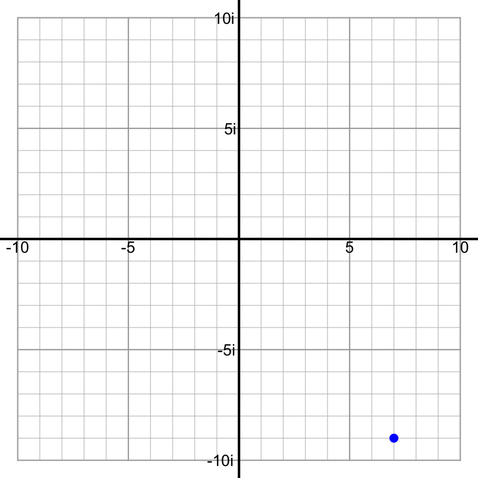

What complex number is represented by the dot?

$-7-9i$$-7+9i$$-9-7i$$-9+7i$$7-9i$$7+9i$$9-7i$$9+7i$

The horizontal (real) component is 7. The vertical (imaginary) component is -9. So, the dot represents $7-9i$.

A dot is shown on the [complex plane](https://en.wikipedia.org/wiki/Complex_plane) below.

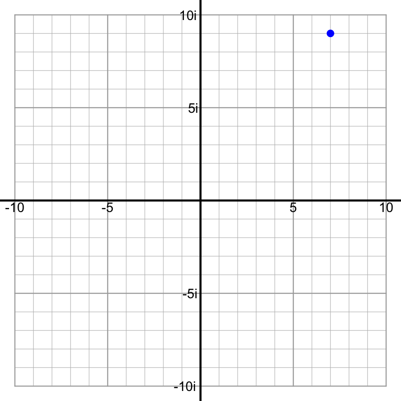

What complex number is represented by the dot?

$-7-9i$$-7+9i$$-9-7i$$-9+7i$$7-9i$$7+9i$$9-7i$$9+7i$

The horizontal (real) component is 7. The vertical (imaginary) component is 9. So, the dot represents $7+9i$.

A dot is shown on the [complex plane](https://en.wikipedia.org/wiki/Complex_plane) below.

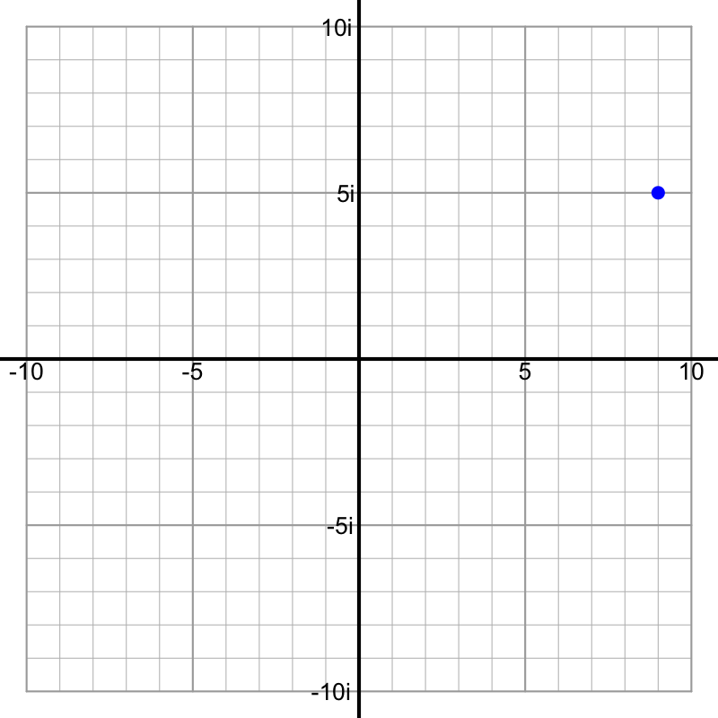

What complex number is represented by the dot?

$-5-9i$$-5+9i$$-9-5i$$-9+5i$$5-9i$$5+9i$$9-5i$$9+5i$

The horizontal (real) component is 9. The vertical (imaginary) component is 5. So, the dot represents $9+5i$.

A dot is shown on the [complex plane](https://en.wikipedia.org/wiki/Complex_plane) below.

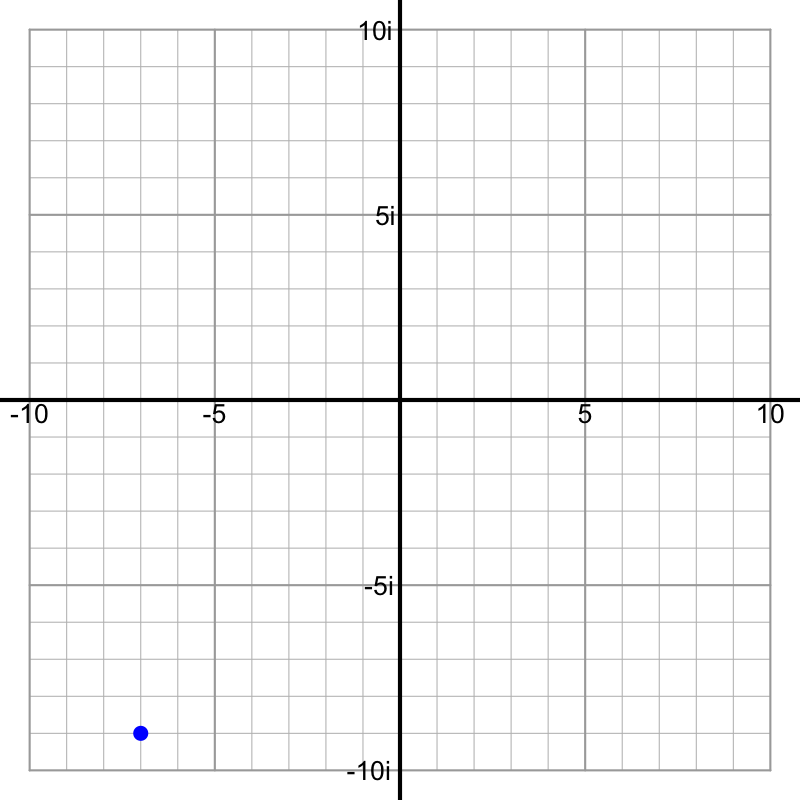

What complex number is represented by the dot?

$-7-9i$$-7+9i$$-9-7i$$-9+7i$$7-9i$$7+9i$$9-7i$$9+7i$

The horizontal (real) component is -7. The vertical (imaginary) component is -9. So, the dot represents $-7-9i$.

A dot is shown on the [complex plane](https://en.wikipedia.org/wiki/Complex_plane) below.

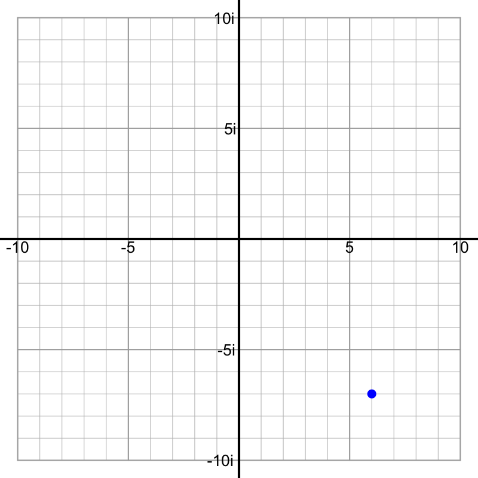

What complex number is represented by the dot?

$-6-7i$$-6+7i$$-7-6i$$-7+6i$$6-7i$$6+7i$$7-6i$$7+6i$

The horizontal (real) component is 6. The vertical (imaginary) component is -7. So, the dot represents $6-7i$.

A dot is shown on the [complex plane](https://en.wikipedia.org/wiki/Complex_plane) below.

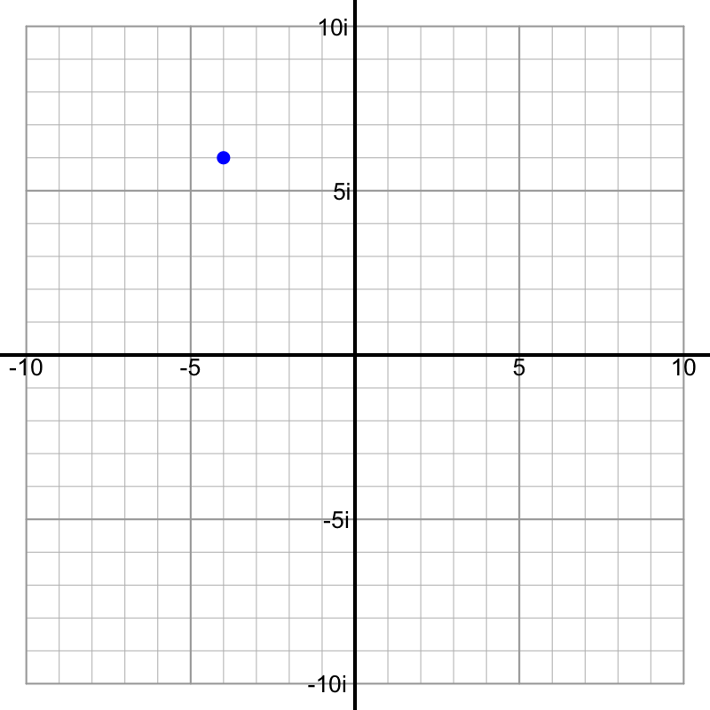

What complex number is represented by the dot?

$-4-6i$$-4+6i$$-6-4i$$-6+4i$$4-6i$$4+6i$$6-4i$$6+4i$

The horizontal (real) component is -4. The vertical (imaginary) component is 6. So, the dot represents $-4+6i$.

A dot is shown on the [complex plane](https://en.wikipedia.org/wiki/Complex_plane) below.

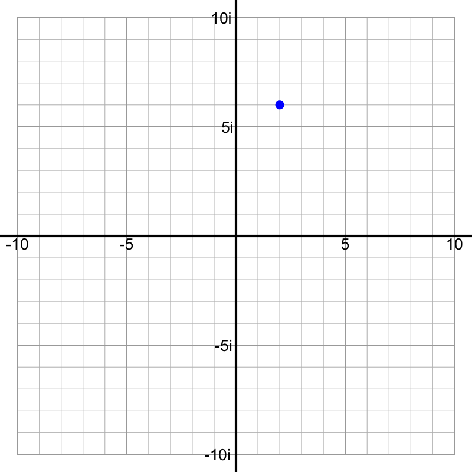

What complex number is represented by the dot?

$-2-6i$$-2+6i$$-6-2i$$-6+2i$$2-6i$$2+6i$$6-2i$$6+2i$

The horizontal (real) component is 2. The vertical (imaginary) component is 6. So, the dot represents $2+6i$.

A dot is shown on the [complex plane](https://en.wikipedia.org/wiki/Complex_plane) below.

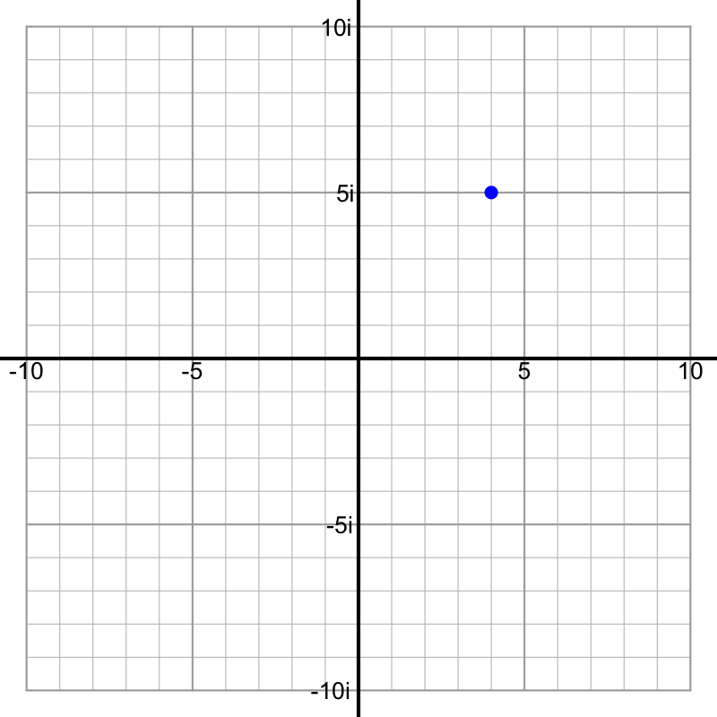

What complex number is represented by the dot?

$-4-5i$$-4+5i$$-5-4i$$-5+4i$$4-5i$$4+5i$$5-4i$$5+4i$

The horizontal (real) component is 4. The vertical (imaginary) component is 5. So, the dot represents $4+5i$.

A dot is shown on the [complex plane](https://en.wikipedia.org/wiki/Complex_plane) below.

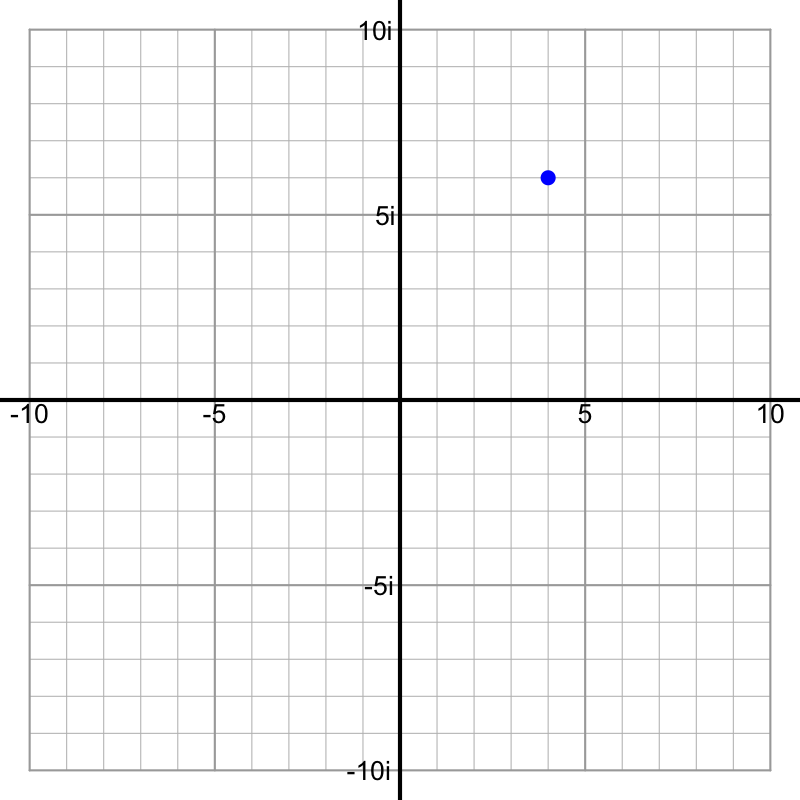

What complex number is represented by the dot?

$-4-6i$$-4+6i$$-6-4i$$-6+4i$$4-6i$$4+6i$$6-4i$$6+4i$

The horizontal (real) component is 4. The vertical (imaginary) component is 6. So, the dot represents $4+6i$.

A dot is shown on the [complex plane](https://en.wikipedia.org/wiki/Complex_plane) below.

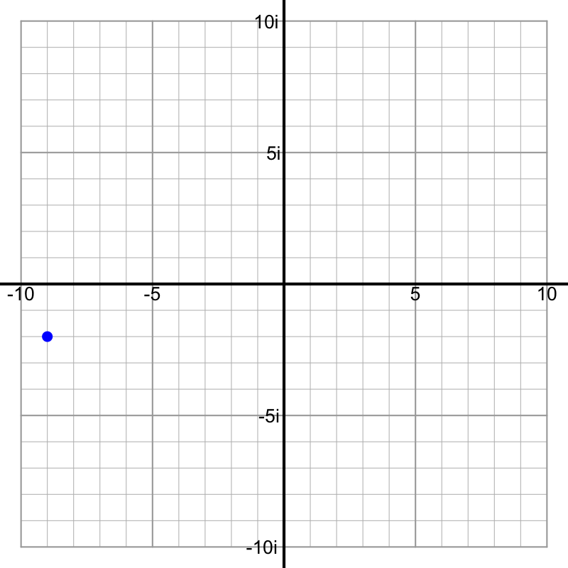

What complex number is represented by the dot?

$-2-9i$$-2+9i$$-9-2i$$-9+2i$$2-9i$$2+9i$$9-2i$$9+2i$

The horizontal (real) component is -9. The vertical (imaginary) component is -2. So, the dot represents $-9-2i$.

Find the sum of the two complex numbers.
$$(-4+7i)+(-9+8i)$$

$-13-15i$$-13-i$$-13+15i$$-13+i$$-5-15i$$-5-i$$-5+15i$$-5+i$$13-15i$$13-i$$13+15i$$13+i$$5-15i$$5-i$$5+15i$$5+i$

For addition, just add the real components $(-4)+(-9)=-13$ and the imaginary components $(7)i+(8)i=15i$.
$$-13+15i$$

Find the sum of the two complex numbers.
$$(-5+3i)+(8-9i)$$

$-13-12i$$-13-6i$$-13+12i$$-13+6i$$-3-12i$$-3-6i$$-3+12i$$-3+6i$$13-12i$$13-6i$$13+12i$$13+6i$$3-12i$$3-6i$$3+12i$$3+6i$

For addition, just add the real components $(-5)+(8)=3$ and the imaginary components $(3)i+(-9)i=-6i$.
$$3-6i$$

Find the sum of the two complex numbers.
$$(7+5i)+(-8+4i)$$

$-1-9i$$-1-i$$-1+9i$$-1+i$$-15-9i$$-15-i$$-15+9i$$-15+i$$1-9i$$1-i$$1+9i$$1+i$$15-9i$$15-i$$15+9i$$15+i$

For addition, just add the real components $(7)+(-8)=-1$ and the imaginary components $(5)i+(4)i=9i$.
$$-1+9i$$

Find the sum of the two complex numbers.
$$(-9+2i)+(4-7i)$$

$-13-5i$$-13-9i$$-13+5i$$-13+9i$$-5-5i$$-5-9i$$-5+5i$$-5+9i$$13-5i$$13-9i$$13+5i$$13+9i$$5-5i$$5-9i$$5+5i$$5+9i$

For addition, just add the real components $(-9)+(4)=-5$ and the imaginary components $(2)i+(-7)i=-5i$.
$$-5-5i$$

Find the sum of the two complex numbers.
$$(2-5i)+(-8-4i)$$

$-10-9i$$-10-i$$-10+9i$$-10+i$$-6-9i$$-6-i$$-6+9i$$-6+i$$10-9i$$10-i$$10+9i$$10+i$$6-9i$$6-i$$6+9i$$6+i$

For addition, just add the real components $(2)+(-8)=-6$ and the imaginary components $(-5)i+(-4)i=-9i$.
$$-6-9i$$

Find the sum of the two complex numbers.
$$(7+9i)+(8-5i)$$

$-1-14i$$-1-4i$$-1+14i$$-1+4i$$-15-14i$$-15-4i$$-15+14i$$-15+4i$$1-14i$$1-4i$$1+14i$$1+4i$$15-14i$$15-4i$$15+14i$$15+4i$

For addition, just add the real components $(7)+(8)=15$ and the imaginary components $(9)i+(-5)i=4i$.
$$15+4i$$

Find the sum of the two complex numbers.
$$(9-5i)+(-4+7i)$$

$-13-12i$$-13-2i$$-13+12i$$-13+2i$$-5-12i$$-5-2i$$-5+12i$$-5+2i$$13-12i$$13-2i$$13+12i$$13+2i$$5-12i$$5-2i$$5+12i$$5+2i$

For addition, just add the real components $(9)+(-4)=5$ and the imaginary components $(-5)i+(7)i=2i$.
$$5+2i$$

Find the sum of the two complex numbers.
$$(-7-3i)+(5-6i)$$

$-12-3i$$-12-9i$$-12+3i$$-12+9i$$-2-3i$$-2-9i$$-2+3i$$-2+9i$$12-3i$$12-9i$$12+3i$$12+9i$$2-3i$$2-9i$$2+3i$$2+9i$

For addition, just add the real components $(-7)+(5)=-2$ and the imaginary components $(-3)i+(-6)i=-9i$.
$$-2-9i$$

Find the sum of the two complex numbers.
$$(8+i)+(7-2i)$$

$-1-3i$$-1-i$$-1+3i$$-1+i$$-15-3i$$-15-i$$-15+3i$$-15+i$$1-3i$$1-i$$1+3i$$1+i$$15-3i$$15-i$$15+3i$$15+i$

For addition, just add the real components $(8)+(7)=15$ and the imaginary components $(1)i+(-2)i=-1i$.
$$15-i$$

Find the sum of the two complex numbers.
$$(1+3i)+(9-8i)$$

$-10-11i$$-10-5i$$-10+11i$$-10+5i$$-8-11i$$-8-5i$$-8+11i$$-8+5i$$10-11i$$10-5i$$10+11i$$10+5i$$8-11i$$8-5i$$8+11i$$8+5i$

For addition, just add the real components $(1)+(9)=10$ and the imaginary components $(3)i+(-8)i=-5i$.
$$10-5i$$

Find the difference of the two complex numbers.
$$(-8-6i)-(-3-i)$$

$-11-5i$$-11-7i$$-11+5i$$-11+7i$$-5-5i$$-5-7i$$-5+5i$$-5+7i$$11-5i$$11-7i$$11+5i$$11+7i$$5-5i$$5-7i$$5+5i$$5+7i$

For subtraction, just subtract the real components $(-8)-(-3)=-5$ and the imaginary components $(-6)i-(-1)i=-5i$.

$$-5-5i$$

Find the difference of the two complex numbers.
$$(-9-5i)-(6+3i)$$

$-15-2i$$-15-8i$$-15+2i$$-15+8i$$-3-2i$$-3-8i$$-3+2i$$-3+8i$$15-2i$$15-8i$$15+2i$$15+8i$$3-2i$$3-8i$$3+2i$$3+8i$

For subtraction, just subtract the real components $(-9)-(6)=-15$ and the imaginary components $(-5)i-(3)i=-8i$.

$$-15-8i$$

Find the difference of the two complex numbers.
$$(-9+8i)-(6-2i)$$

$-15-10i$$-15-6i$$-15+10i$$-15+6i$$-3-10i$$-3-6i$$-3+10i$$-3+6i$$15-10i$$15-6i$$15+10i$$15+6i$$3-10i$$3-6i$$3+10i$$3+6i$

For subtraction, just subtract the real components $(-9)-(6)=-15$ and the imaginary components $(8)i-(-2)i=10i$.

$$-15+10i$$

Find the difference of the two complex numbers.
$$(3-7i)-(-8+i)$$

$-11-6i$$-11-8i$$-11+6i$$-11+8i$$-5-6i$$-5-8i$$-5+6i$$-5+8i$$11-6i$$11-8i$$11+6i$$11+8i$$5-6i$$5-8i$$5+6i$$5+8i$

For subtraction, just subtract the real components $(3)-(-8)=11$ and the imaginary components $(-7)i-(1)i=-8i$.

$$11-8i$$

Find the difference of the two complex numbers.
$$(9+7i)-(6-5i)$$

$-15-12i$$-15-2i$$-15+12i$$-15+2i$$-3-12i$$-3-2i$$-3+12i$$-3+2i$$15-12i$$15-2i$$15+12i$$15+2i$$3-12i$$3-2i$$3+12i$$3+2i$

For subtraction, just subtract the real components $(9)-(6)=3$ and the imaginary components $(7)i-(-5)i=12i$.

$$3+12i$$

Find the difference of the two complex numbers.
$$(2-7i)-(8+3i)$$

$-10-10i$$-10-4i$$-10+10i$$-10+4i$$-6-10i$$-6-4i$$-6+10i$$-6+4i$$10-10i$$10-4i$$10+10i$$10+4i$$6-10i$$6-4i$$6+10i$$6+4i$

For subtraction, just subtract the real components $(2)-(8)=-6$ and the imaginary components $(-7)i-(3)i=-10i$.

$$-6-10i$$

Find the difference of the two complex numbers.
$$(-8+3i)-(9+5i)$$

$-1-2i$$-1-8i$$-1+2i$$-1+8i$$-17-2i$$-17-8i$$-17+2i$$-17+8i$$1-2i$$1-8i$$1+2i$$1+8i$$17-2i$$17-8i$$17+2i$$17+8i$

For subtraction, just subtract the real components $(-8)-(9)=-17$ and the imaginary components $(3)i-(5)i=-2i$.

$$-17-2i$$

Find the difference of the two complex numbers.
$$(4+9i)-(8+3i)$$

$-12-12i$$-12-6i$$-12+12i$$-12+6i$$-4-12i$$-4-6i$$-4+12i$$-4+6i$$12-12i$$12-6i$$12+12i$$12+6i$$4-12i$$4-6i$$4+12i$$4+6i$

For subtraction, just subtract the real components $(4)-(8)=-4$ and the imaginary components $(9)i-(3)i=6i$.

$$-4+6i$$

Find the difference of the two complex numbers.
$$(7-4i)-(-1+9i)$$

$-6-13i$$-6-5i$$-6+13i$$-6+5i$$-8-13i$$-8-5i$$-8+13i$$-8+5i$$6-13i$$6-5i$$6+13i$$6+5i$$8-13i$$8-5i$$8+13i$$8+5i$

For subtraction, just subtract the real components $(7)-(-1)=8$ and the imaginary components $(-4)i-(9)i=-13i$.

$$8-13i$$

Find the difference of the two complex numbers.
$$(6-3i)-(8+i)$$

$-14-2i$$-14-4i$$-14+2i$$-14+4i$$-2-2i$$-2-4i$$-2+2i$$-2+4i$$14-2i$$14-4i$$14+2i$$14+4i$$2-2i$$2-4i$$2+2i$$2+4i$

For subtraction, just subtract the real components $(6)-(8)=-2$ and the imaginary components $(-3)i-(1)i=-4i$.

$$-2-4i$$

Find the product of the two complex numbers.
$$(-2-9i)\cdot(-5+3i)$$

$-10-27i$$-10-39i$$-10-51i$$-10+27i$$-10+39i$$-10+51i$$-17-27i$$-17-39i$$-17-51i$$-17+27i$$-17+39i$$-17+51i$$-37-27i$$-37-39i$$-37-51i$$-37+27i$$-37+39i$$-37+51i$$10-27i$$10-39i$$10-51i$$10+27i$$10+39i$$10+51i$$17-27i$$17-39i$$17-51i$$17+27i$$17+39i$$17+51i$$37-27i$$37-39i$$37-51i$$37+27i$$37+39i$$37+51i$

To multiply complex numbers, follow a procedure similar to [FOIL](https://en.wikipedia.org/wiki/FOIL_method), but remember $i^2=-1$.

$$(-2-9i)(-5+3i)$$

$$\Big((-2)+(-9i)\Big)\Big((-5)+(3i)\Big)$$

$$(-2)(-5)~~+~~(-2)(3i)~~+~~(-9i)(-5)~~+~~(-9i)(3i)$$
$$(10)~~+~~(-6)i~~+~~(45)i
~~+~~(-27)i^2$$

You could also use a box to multiply.

| * | $-2$ | $-9i$ |
| --- | --- | --- |
| $-5$ | $10$ | $45i$ |
| $3i$ | $-6i$ | $-27i^2$ |

$$(10)~~+~~(-6)i~~+~~(45)i
~~+~~(-27)i^2$$

Remember that $i^2=-1$.

$$(10)~~+~~(-6)i~~+~~(45)i~~+~~(27)$$

Let's group similar terms. We put the real terms to the left and the imaginary terms to the right.

$$(10)~~+~~(27)~~+~~(-6)i~~+~~(45)i$$
Combine the real terms and combine the imaginary terms.

$$37+39i$$

Find the product of the two complex numbers.
$$(-1+5i)\cdot(4-2i)$$

$-14-10i$$-14-18i$$-14-22i$$-14+10i$$-14+18i$$-14+22i$$-4-10i$$-4-18i$$-4-22i$$-4+10i$$-4+18i$$-4+22i$$-6-10i$$-6-18i$$-6-22i$$-6+10i$$-6+18i$$-6+22i$$14-10i$$14-18i$$14-22i$$14+10i$$14+18i$$14+22i$$4-10i$$4-18i$$4-22i$$4+10i$$4+18i$$4+22i$$6-10i$$6-18i$$6-22i$$6+10i$$6+18i$$6+22i$

To multiply complex numbers, follow a procedure similar to [FOIL](https://en.wikipedia.org/wiki/FOIL_method), but remember $i^2=-1$.

$$(-1+5i)(4-2i)$$

$$\Big((-1)+(5i)\Big)\Big((4)+(-2i)\Big)$$

$$(-1)(4)~~+~~(-1)(-2i)~~+~~(5i)(4)~~+~~(5i)(-2i)$$
$$(-4)~~+~~(2)i~~+~~(20)i
~~+~~(-10)i^2$$

You could also use a box to multiply.

| * | $-1$ | $5i$ |
| --- | --- | --- |
| $4$ | $-4$ | $20i$ |
| $-2i$ | $2i$ | $-10i^2$ |

$$(-4)~~+~~(2)i~~+~~(20)i
~~+~~(-10)i^2$$

Remember that $i^2=-1$.

$$(-4)~~+~~(2)i~~+~~(20)i~~+~~(10)$$

Let's group similar terms. We put the real terms to the left and the imaginary terms to the right.

$$(-4)~~+~~(10)~~+~~(2)i~~+~~(20)i$$
Combine the real terms and combine the imaginary terms.

$$6+22i$$

Find the product of the two complex numbers.
$$(-3+9i)\cdot(5-6i)$$

$-15-27i$$-15-54i$$-15-63i$$-15+27i$$-15+54i$$-15+63i$$-39-27i$$-39-54i$$-39-63i$$-39+27i$$-39+54i$$-39+63i$$-69-27i$$-69-54i$$-69-63i$$-69+27i$$-69+54i$$-69+63i$$15-27i$$15-54i$$15-63i$$15+27i$$15+54i$$15+63i$$39-27i$$39-54i$$39-63i$$39+27i$$39+54i$$39+63i$$69-27i$$69-54i$$69-63i$$69+27i$$69+54i$$69+63i$

To multiply complex numbers, follow a procedure similar to [FOIL](https://en.wikipedia.org/wiki/FOIL_method), but remember $i^2=-1$.

$$(-3+9i)(5-6i)$$

$$\Big((-3)+(9i)\Big)\Big((5)+(-6i)\Big)$$

$$(-3)(5)~~+~~(-3)(-6i)~~+~~(9i)(5)~~+~~(9i)(-6i)$$
$$(-15)~~+~~(18)i~~+~~(45)i
~~+~~(-54)i^2$$

You could also use a box to multiply.

| * | $-3$ | $9i$ |
| --- | --- | --- |
| $5$ | $-15$ | $45i$ |
| $-6i$ | $18i$ | $-54i^2$ |

$$(-15)~~+~~(18)i~~+~~(45)i
~~+~~(-54)i^2$$

Remember that $i^2=-1$.

$$(-15)~~+~~(18)i~~+~~(45)i~~+~~(54)$$

Let's group similar terms. We put the real terms to the left and the imaginary terms to the right.

$$(-15)~~+~~(54)~~+~~(18)i~~+~~(45)i$$
Combine the real terms and combine the imaginary terms.

$$39+63i$$

Find the product of the two complex numbers.
$$(2+8i)\cdot(1+3i)$$

$-2-14i$$-2-24i$$-2-2i$$-2+14i$$-2+24i$$-2+2i$$-22-14i$$-22-24i$$-22-2i$$-22+14i$$-22+24i$$-22+2i$$-26-14i$$-26-24i$$-26-2i$$-26+14i$$-26+24i$$-26+2i$$2-14i$$2-24i$$2-2i$$2+14i$$2+24i$$2+2i$$22-14i$$22-24i$$22-2i$$22+14i$$22+24i$$22+2i$$26-14i$$26-24i$$26-2i$$26+14i$$26+24i$$26+2i$

To multiply complex numbers, follow a procedure similar to [FOIL](https://en.wikipedia.org/wiki/FOIL_method), but remember $i^2=-1$.

$$(2+8i)(1+3i)$$

$$\Big((2)+(8i)\Big)\Big((1)+(3i)\Big)$$

$$(2)(1)~~+~~(2)(3i)~~+~~(8i)(1)~~+~~(8i)(3i)$$
$$(2)~~+~~(6)i~~+~~(8)i
~~+~~(24)i^2$$

You could also use a box to multiply.

| * | $2$ | $8i$ |
| --- | --- | --- |
| $1$ | $2$ | $8i$ |
| $3i$ | $6i$ | $24i^2$ |

$$(2)~~+~~(6)i~~+~~(8)i
~~+~~(24)i^2$$

Remember that $i^2=-1$.

$$(2)~~+~~(6)i~~+~~(8)i~~+~~(-24)$$

Let's group similar terms. We put the real terms to the left and the imaginary terms to the right.

$$(2)~~+~~(-24)~~+~~(6)i~~+~~(8)i$$
Combine the real terms and combine the imaginary terms.

$$-22+14i$$

Find the product of the two complex numbers.
$$(6-3i)\cdot(1+8i)$$

$-18-24i$$-18-45i$$-18-51i$$-18+24i$$-18+45i$$-18+51i$$-30-24i$$-30-45i$$-30-51i$$-30+24i$$-30+45i$$-30+51i$$-6-24i$$-6-45i$$-6-51i$$-6+24i$$-6+45i$$-6+51i$$18-24i$$18-45i$$18-51i$$18+24i$$18+45i$$18+51i$$30-24i$$30-45i$$30-51i$$30+24i$$30+45i$$30+51i$$6-24i$$6-45i$$6-51i$$6+24i$$6+45i$$6+51i$

To multiply complex numbers, follow a procedure similar to [FOIL](https://en.wikipedia.org/wiki/FOIL_method), but remember $i^2=-1$.

$$(6-3i)(1+8i)$$

$$\Big((6)+(-3i)\Big)\Big((1)+(8i)\Big)$$

$$(6)(1)~~+~~(6)(8i)~~+~~(-3i)(1)~~+~~(-3i)(8i)$$
$$(6)~~+~~(48)i~~+~~(-3)i
~~+~~(-24)i^2$$

You could also use a box to multiply.

| * | $6$ | $-3i$ |
| --- | --- | --- |
| $1$ | $6$ | $-3i$ |
| $8i$ | $48i$ | $-24i^2$ |

$$(6)~~+~~(48)i~~+~~(-3)i
~~+~~(-24)i^2$$

Remember that $i^2=-1$.

$$(6)~~+~~(48)i~~+~~(-3)i~~+~~(24)$$

Let's group similar terms. We put the real terms to the left and the imaginary terms to the right.

$$(6)~~+~~(24)~~+~~(48)i~~+~~(-3)i$$
Combine the real terms and combine the imaginary terms.

$$30+45i$$

Find the product of the two complex numbers.
$$(4-5i)\cdot(-2+8i)$$

$-32-22i$$-32-40i$$-32-42i$$-32+22i$$-32+40i$$-32+42i$$-48-22i$$-48-40i$$-48-42i$$-48+22i$$-48+40i$$-48+42i$$-8-22i$$-8-40i$$-8-42i$$-8+22i$$-8+40i$$-8+42i$$32-22i$$32-40i$$32-42i$$32+22i$$32+40i$$32+42i$$48-22i$$48-40i$$48-42i$$48+22i$$48+40i$$48+42i$$8-22i$$8-40i$$8-42i$$8+22i$$8+40i$$8+42i$

To multiply complex numbers, follow a procedure similar to [FOIL](https://en.wikipedia.org/wiki/FOIL_method), but remember $i^2=-1$.

$$(4-5i)(-2+8i)$$

$$\Big((4)+(-5i)\Big)\Big((-2)+(8i)\Big)$$

$$(4)(-2)~~+~~(4)(8i)~~+~~(-5i)(-2)~~+~~(-5i)(8i)$$
$$(-8)~~+~~(32)i~~+~~(10)i
~~+~~(-40)i^2$$

You could also use a box to multiply.

| * | $4$ | $-5i$ |
| --- | --- | --- |
| $-2$ | $-8$ | $10i$ |
| $8i$ | $32i$ | $-40i^2$ |

$$(-8)~~+~~(32)i~~+~~(10)i
~~+~~(-40)i^2$$

Remember that $i^2=-1$.

$$(-8)~~+~~(32)i~~+~~(10)i~~+~~(40)$$

Let's group similar terms. We put the real terms to the left and the imaginary terms to the right.

$$(-8)~~+~~(40)~~+~~(32)i~~+~~(10)i$$
Combine the real terms and combine the imaginary terms.

$$32+42i$$

Find the product of the two complex numbers.
$$(2+5i)\cdot(9+4i)$$

$-18-20i$$-18-37i$$-18-53i$$-18+20i$$-18+37i$$-18+53i$$-2-20i$$-2-37i$$-2-53i$$-2+20i$$-2+37i$$-2+53i$$-38-20i$$-38-37i$$-38-53i$$-38+20i$$-38+37i$$-38+53i$$18-20i$$18-37i$$18-53i$$18+20i$$18+37i$$18+53i$$2-20i$$2-37i$$2-53i$$2+20i$$2+37i$$2+53i$$38-20i$$38-37i$$38-53i$$38+20i$$38+37i$$38+53i$

To multiply complex numbers, follow a procedure similar to [FOIL](https://en.wikipedia.org/wiki/FOIL_method), but remember $i^2=-1$.

$$(2+5i)(9+4i)$$

$$\Big((2)+(5i)\Big)\Big((9)+(4i)\Big)$$

$$(2)(9)~~+~~(2)(4i)~~+~~(5i)(9)~~+~~(5i)(4i)$$
$$(18)~~+~~(8)i~~+~~(45)i
~~+~~(20)i^2$$

You could also use a box to multiply.

| * | $2$ | $5i$ |
| --- | --- | --- |
| $9$ | $18$ | $45i$ |
| $4i$ | $8i$ | $20i^2$ |

$$(18)~~+~~(8)i~~+~~(45)i
~~+~~(20)i^2$$

Remember that $i^2=-1$.

$$(18)~~+~~(8)i~~+~~(45)i~~+~~(-20)$$

Let's group similar terms. We put the real terms to the left and the imaginary terms to the right.

$$(18)~~+~~(-20)~~+~~(8)i~~+~~(45)i$$
Combine the real terms and combine the imaginary terms.

$$-2+53i$$

Find the product of the two complex numbers.
$$(9-i)\cdot(-3-6i)$$

$-21-51i$$-21-57i$$-21-6i$$-21+51i$$-21+57i$$-21+6i$$-27-51i$$-27-57i$$-27-6i$$-27+51i$$-27+57i$$-27+6i$$-33-51i$$-33-57i$$-33-6i$$-33+51i$$-33+57i$$-33+6i$$21-51i$$21-57i$$21-6i$$21+51i$$21+57i$$21+6i$$27-51i$$27-57i$$27-6i$$27+51i$$27+57i$$27+6i$$33-51i$$33-57i$$33-6i$$33+51i$$33+57i$$33+6i$

To multiply complex numbers, follow a procedure similar to [FOIL](https://en.wikipedia.org/wiki/FOIL_method), but remember $i^2=-1$.

$$(9-i)(-3-6i)$$

$$\Big((9)+(-1i)\Big)\Big((-3)+(-6i)\Big)$$

$$(9)(-3)~~+~~(9)(-6i)~~+~~(-1i)(-3)~~+~~(-1i)(-6i)$$
$$(-27)~~+~~(-54)i~~+~~(3)i
~~+~~(6)i^2$$

You could also use a box to multiply.

| * | $9$ | $-1i$ |
| --- | --- | --- |
| $-3$ | $-27$ | $3i$ |
| $-6i$ | $-54i$ | $6i^2$ |

$$(-27)~~+~~(-54)i~~+~~(3)i
~~+~~(6)i^2$$

Remember that $i^2=-1$.

$$(-27)~~+~~(-54)i~~+~~(3)i~~+~~(-6)$$

Let's group similar terms. We put the real terms to the left and the imaginary terms to the right.

$$(-27)~~+~~(-6)~~+~~(-54)i~~+~~(3)i$$
Combine the real terms and combine the imaginary terms.

$$-33-51i$$

Find the product of the two complex numbers.
$$(8+i)\cdot(-7-4i)$$

$-52-25i$$-52-39i$$-52-4i$$-52+25i$$-52+39i$$-52+4i$$-56-25i$$-56-39i$$-56-4i$$-56+25i$$-56+39i$$-56+4i$$-60-25i$$-60-39i$$-60-4i$$-60+25i$$-60+39i$$-60+4i$$52-25i$$52-39i$$52-4i$$52+25i$$52+39i$$52+4i$$56-25i$$56-39i$$56-4i$$56+25i$$56+39i$$56+4i$$60-25i$$60-39i$$60-4i$$60+25i$$60+39i$$60+4i$

To multiply complex numbers, follow a procedure similar to [FOIL](https://en.wikipedia.org/wiki/FOIL_method), but remember $i^2=-1$.

$$(8+i)(-7-4i)$$

$$\Big((8)+(1i)\Big)\Big((-7)+(-4i)\Big)$$

$$(8)(-7)~~+~~(8)(-4i)~~+~~(1i)(-7)~~+~~(1i)(-4i)$$
$$(-56)~~+~~(-32)i~~+~~(-7)i
~~+~~(-4)i^2$$

You could also use a box to multiply.

| * | $8$ | $1i$ |
| --- | --- | --- |
| $-7$ | $-56$ | $-7i$ |
| $-4i$ | $-32i$ | $-4i^2$ |

$$(-56)~~+~~(-32)i~~+~~(-7)i
~~+~~(-4)i^2$$

Remember that $i^2=-1$.

$$(-56)~~+~~(-32)i~~+~~(-7)i~~+~~(4)$$

Let's group similar terms. We put the real terms to the left and the imaginary terms to the right.

$$(-56)~~+~~(4)~~+~~(-32)i~~+~~(-7)i$$
Combine the real terms and combine the imaginary terms.

$$-52-39i$$

Find the product of the two complex numbers.
$$(3+i)\cdot(-9-2i)$$

$-25-15i$$-25-2i$$-25-3i$$-25+15i$$-25+2i$$-25+3i$$-27-15i$$-27-2i$$-27-3i$$-27+15i$$-27+2i$$-27+3i$$-29-15i$$-29-2i$$-29-3i$$-29+15i$$-29+2i$$-29+3i$$25-15i$$25-2i$$25-3i$$25+15i$$25+2i$$25+3i$$27-15i$$27-2i$$27-3i$$27+15i$$27+2i$$27+3i$$29-15i$$29-2i$$29-3i$$29+15i$$29+2i$$29+3i$

To multiply complex numbers, follow a procedure similar to [FOIL](https://en.wikipedia.org/wiki/FOIL_method), but remember $i^2=-1$.

$$(3+i)(-9-2i)$$

$$\Big((3)+(1i)\Big)\Big((-9)+(-2i)\Big)$$

$$(3)(-9)~~+~~(3)(-2i)~~+~~(1i)(-9)~~+~~(1i)(-2i)$$
$$(-27)~~+~~(-6)i~~+~~(-9)i
~~+~~(-2)i^2$$

You could also use a box to multiply.

| * | $3$ | $1i$ |
| --- | --- | --- |
| $-9$ | $-27$ | $-9i$ |
| $-2i$ | $-6i$ | $-2i^2$ |

$$(-27)~~+~~(-6)i~~+~~(-9)i
~~+~~(-2)i^2$$

Remember that $i^2=-1$.

$$(-27)~~+~~(-6)i~~+~~(-9)i~~+~~(2)$$

Let's group similar terms. We put the real terms to the left and the imaginary terms to the right.

$$(-27)~~+~~(2)~~+~~(-6)i~~+~~(-9)i$$
Combine the real terms and combine the imaginary terms.

$$-25-15i$$